# Lab_3_Solution

```python
import pandas as pd
import numpy as np
import matplotlib.pyplot as plt
```

Question 1: Read in the file 'listings' that contains the listings for the Boston AirBnBs. How many entries are in the file? How many unique identifiers are there for AirBnB listings?

```python
listings = pd.read_csv('listings-1.csv')
```

```python
listings.shape
```

```
(6264, 106)
```

```python
listings.id.nunique()
```

```
6264
```

Question 2: Read in the 'reviews' file that contains the date of reviews for the Boston AirBnB listings. How many entries are in the file? How many unique identifiers are there for AirBnB listings? Do all of the listings have a corresponding review?

```python
reviews = pd.read_csv('reviews.csv')
```

```python
reviews.shape
```

```
(225880, 2)
```

```python
reviews.listing_id.nunique()
```

```
5088
```

Not all of the listings have a corresponding review. There are 5088 listings with reviews and 6264 total listings.

Question 3: Merge the review and listing files. Do a merge using the function 'pd.merge' so that all of the entries from listing are in the merged data frame and have an NaN if there is no corresponding entry in reviews. How many rows do you now have? How many unique AirBnB ids do you have? How many rows were filled in with NaN?

```python
listings_reviews_left = pd.merge(listings, reviews, left_on = 'id', right_on = 'listing_id', how = 'left')
```

```python
listings_reviews_left.shape
```

```
(227056, 108)
```

```python
listings_reviews_left.id.nunique()
```

```
6264
```

```python
sum(listings_reviews_left.date.isnull())
```

```
1176
```

Question 4: Merge the review and listing files again using 'pd.merge'. This time do a merge so that all of the entries from reviews are in the dataframe (and therefore any entries from listings that do not have a review are dropped). How many rows do you now have? How many unique AirBnB ids do you have?

Answer: This can be done with either a right join (since all of the entires in reviews are in listings) or an inner join.

```python
listings_reviews_right = pd.merge(listings, reviews, left_on = 'id', right_on = 'listing_id', how = 'right')
```

```python
listings_reviews_right.shape
```

```
(225880, 108)
```

```python
listings_reviews_right.id.nunique()
```

```
5088
```

```python
listings_reviews_inner = pd.merge(listings, reviews, left_on = 'id', right_on = 'listing_id', how = 'inner')
```

```python
listings_reviews_inner.shape
```

```
(225880, 108)
```

```python
listings_reviews_inner.id.nunique()
```

```
5088
```

Question 5: Accoring to AirBnB superhosts 'are experienced hosts who provide a shining example for other hosts, and extraordinary experiences for their guests'. How many unique AirBnBs are hosted by a 'superhost' in Boston? How many superhosts are there in Boston? How many super hosts do not have any reviews in the 'reviews' dataset? What is the median number of reviews that a superhost has in the 'reviews' dataset?

```python
listings.superhost = listings[listings.host_is_superhost == 't']
```

```python
listings.superhost.id.nunique()
```

```
1448
```

```python
listings.superhost.host_id.nunique()
```

```
757
```

```python
listings.superhost = pd.merge(listings.superhost, reviews, left_on = 'id', right_on = 'listing_id', how = 'left')
```

```python
sum(listings.superhost.date.isnull())
```

```
70
```

```python
listings.superhost.groupby('id').date.count().median()
```

```
41.0
```

Question 6: Make boxplots to compare the number of reviews of superhosts to non-superhosts. Hint: the boxplots may look better if you log the counts!

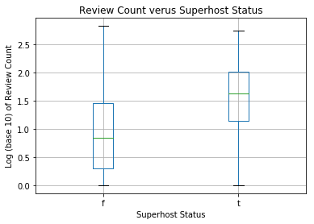

```python
listings.superhost = listings_reviews_left.groupby(['id', 'host_is_superhost']).date.count().unstack()
listings.superhost.f = np.log10(listings.superhost.f + 1)
listings.superhost.t = np.log10(listings.superhost.t + 1)
listings.superhost.boxplot()
plt.ylabel('Log (base 10) of Review Count')
plt.xlabel('Superhost Status')
plt.title('Review Count verus Superhost Status')
```